# No evidence that frontal eye field tDCS affects latency or accuracy of prosaccades

Leon Reteig, Tomas Knapen, Richard Ridderinkhof, Heleen Slagter

# Group analyses

## Load data

All (meta)data are stored as `.csv` files in the `/data` folder.

### Eye tracking data

Here we load the `.csv` file with the processed eye tracking data, which was created in MATLAB. To recreate it from the raw data, run the `analysis.m` script. This scripts calls the `processEDF.m` function to parse the raw eye tracking data.

- **subject**: subject ID
- **stimulation**: Whether data are from the `anodal` or `cathodal` session
- **leg**: Whether data are before (`pre`), during (`tDCS`), or after (`post`) tDCS
- **block**: After each block participant had a brief break and tracker was recalibrated
- **trial**: trial number within a block
- **type**:
  - `lateral` - fixation in center of display, saccade made towards the periphery
  - `center` - fixation in periphery, saccade made back towards the center of the display
- **direction**: `left` for saccades towards the left of current fixation position; `right` for saccades to the right
- **deviation.start** : distance (in visual angle) from saccade start point to fixation
- **deviation.end.x**: distance (in visual angle) from x-coordinate of saccade end point to x-coordinate of target location
- **deviation.end.y**: same for y-coordinate
- **amplitude**: distance (in visual angle) between saccade start and end point
- **latency**: time (in ms) from target onset to start of saccade
- **drift.x**: distance (in visual angle) between x-coordinate of average fixation position during the break to x-coordinate of fixation stimulus. This stimulus was displayed at each break in the task, so this data can be used as an estimate of offsets to do drift correction.
- **drift.y**: same for y-coordinate

### Metadata

#### Session info

```r
kable(head(sessionData))
```

| subject | session | stimulation | date | day | time |
| --- | --- | --- | --- | --- | --- |
| S01 | first | cathodal | 10/07/15 | Friday | 11:30:00 |
| S01 | second | anodal | 16/07/15 | Thursday | 09:00:00 |
| S02 | first | anodal | 10/07/15 | Friday | 09:00:00 |
| S02 | second | cathodal | 13/07/15 | Monday | 09:00:00 |
| S03 | first | cathodal | 13/07/15 | Monday | 11:30:00 |
| S03 | second | anodal | 15/07/15 | Wednesday | 13:00:00 |

#### Subject info

```r
# Load eye tracking data into data frame
dataFile <- here("data", "subject_info.csv")
subjectData <- read_csv2(dataFile, col_names = TRUE, progress = FALSE, col_types = cols(
  session.order = col_factor(c("first.anodal", "first.cathodal"))
))
```

```r
kable(head(subjectData))
```

| subject | session.order | gender | age | dominant.eye |
| --- | --- | --- | --- | --- |
| S01 | first.cathodal | female | 23 | right |
| S02 | first.anodal | male | 27 | left |
| S03 | first.cathodal | male | 34 | right |
| S04 | first.anodal | male | NA | right |
| S05 | first.cathodal | male | 24 | right |
| S06 | first.cathodal | female | 29 | left |

- **subject**: subject ID
- **session.order**: Whether subject had anodal stimulation in the first session (`first.anodal`) or cathodal stimulation in the first session (`first.cathodal`)
- **gender**
- **age**: in years
- **dominant.eye**: result of eye dominance test

## Preprocess eye data

*See the `inspection.html` notebook for more explanation and exploration of preprocessing, outlier saccades and subject exclusion*

### Reject outlier saccades

```r
tooFast <- 50
tooSlow <- 400
badFix <- 1.8
badSacc <- 8
```

Criteria for outliers:

- Discard fast saccades, with a latency of 50 ms or less
- Discard slow saccades, saccades with a latency of 400 ms or more
- Discard inaccurate fixations, with saccade starting point more than 1.8 degrees or more away from fixation
- Discard faulty saccades, with x-coordinate of saccade end point 8 degree or more away from the target

```r
# Mark outliers
groupData <- mutate(groupData, outlier = "non.outlier", # fill vector for all saccades
                    outlier = ifelse(latency < tooFast, "fast", outlier), # mark too fast saccades as "fast"
                    outlier = ifelse(latency > tooSlow, "slow", outlier), # mark too slow saccades as "slow"
                    outlier = ifelse(deviation.start > badFix, "fixation", outlier), # mark bad fixations as "fixation"
                    outlier = ifelse(deviation.end.x > badSacc, "saccade", outlier), # mark inaccurate saccades as "saccade"
                    outlier = ifelse(is.na(latency), "none", outlier) # mark absence of saccade as "none"
                    )
```

```r
preproc <- filter(groupData, outlier == "non.outlier")
```

### Exclude participants

- S21 and S25 were tested < 48h apart
- S16, S22 and S28 have fewer than 50 saccades per condition after trial rejection

```r
subs2exclude <- c("S21","S25","S16","S22","S28")
```

```r
preproc <- filter(preproc, !(subject %in% subs2exclude))
```

### Collapse data across 15 minute intervals

Cut the post-block into two so we have four 15-minute intervals: one before, one during, and two after stimulation.

```r
preproc <- preproc %>%
  mutate(leg = as.character(leg), # cannot edit leg if it's still a factor
         leg = replace(leg, leg == "post" & block <= 3, "post.1"),
         leg = replace(leg, block > 3, "post.2"),
         leg = factor(leg, levels = c("pre", "tDCS", "post.1", "post.2")) # refactor and order levels
         )
```

## Subject and session descriptives

### Sample demographics

For S23, no eye data was collected because eye tracker could not be calibrated, so here we don’t include their subject/session data.

**Gender of remaining participants:**

```r
subjectData %>%
  filter(!(subject %in% c(subs2exclude, "S23"))) %>% # remove rows with these subject
  group_by(gender) %>% # for each gender
  summarise(count = n_distinct(subject)) %>%
  kable(.)# count number of subjects
```

| gender | count |
| --- | --- |
| female | 14 |
| male | 12 |

**Age:**

```r
subjectData %>%
  filter(!(subject %in% c(subs2exclude, "S23"))) %>%
  summarise_at(vars(age), funs(mean, min, max, sd), na.rm = TRUE) %>% # apply summary functions to age column
  kable(.)
```

| mean | min | max | sd |
| --- | --- | --- | --- |
| 25.90476 | 21 | 34 | 3.419134 |

### tDCS session order

```r
sessionData %>%
  filter(!(subject %in% c(subs2exclude, "S23"))) %>%
  group_by(session, stimulation) %>%
  summarise(count = n_distinct(subject)) %>%
  kable(.)
```

| session | stimulation | count |
| --- | --- | --- |
| first | anodal | 14 |
| first | cathodal | 12 |
| second | anodal | 12 |
| second | cathodal | 14 |

### Saccade counts

Average number of saccades per type after rejection:

```r
preproc %>%
  group_by(subject,stimulation,leg,direction,type) %>% # for each cell
  summarise(saccades = n()) %>% # count how many saccacdes there are left
  group_by(type) %>%
  summarise_at(vars(saccades), funs(mean, min, max, sd)) %>% # compute summary statistics per type
  kable(.)
```

| type | mean | min | max | sd |
| --- | --- | --- | --- | --- |
| lateral | 175.2284 | 142 | 180 | 6.244285 |
| center | 155.5529 | 74 | 180 | 20.816516 |

Percentage of outlier saccades per type out of all sacccades:

```r
n_total <- nrow(filter(groupData, !(subject %in% subs2exclude)))  # total amount of saccades across all included sessions/subjects
groupData %>%
  filter(!(subject %in% subs2exclude), !(outlier %in% c("non.outlier", "none"))) %>%
  group_by(subject,stimulation,leg,direction,type,outlier) %>%
  summarize(outlier_count = n()) %>% # for each condition and subject, count how many (non)outliers there are
  group_by(outlier) %>% # for each outlier type
  summarise(percentage = sum(outlier_count) / n_total *100) %>% # calculate percentage
  kable(.)
```

| outlier | percentage |
| --- | --- |
| fast | 1.9958600 |
| fixation | 2.5848024 |
| saccade | 0.1555823 |
| slow | 0.1161859 |

## Saccade latency

*See the `median_latency.html` notebook for more explanation and exploration of the median saccade latency data*

Compute the median for each 3 blocks

```r
latencyMedianLeg <- preproc %>%
  group_by(subject,stimulation,direction,type) %>%
  summarise(baseline = median(latency[leg == "pre"]), # take average of 3 blocks, make new column
            tDCS = median(latency[leg == "tDCS"]),
            post.1 = median(latency[leg == "post.1"]),
            post.2 = median(latency[leg == "post.2"])) %>%
  gather(leg,latency,baseline,tDCS,post.1,post.2) %>% # gather new columns to use as factor
  mutate(leg = factor(leg, levels = c("baseline", "tDCS", "post.1", "post.2"))) # reorder factor levels
```

Make a separate data frame where the median baseline latency is subtracted from subsequent blocks

```r
latencyMedianBaseline <- latencyMedianLeg %>%
  group_by(subject,stimulation,direction,type) %>% # for each condition, subtract baseline scores and make new columns
  summarise(baseline = latency[leg == "baseline"] - latency[leg == "baseline"],
           tDCS = latency[leg == "tDCS"] - latency[leg == "baseline"],
           post.1 = latency[leg == "post.1"] - latency[leg == "baseline"],
           post.2 = latency[leg == "post.2"] - latency[leg == "baseline"]) %>%
  gather(leg, latency.baseline, baseline, tDCS, post.1, post.2)  %>% # gather new columns to use as factor
  mutate(leg = factor(leg, levels = c("baseline", "tDCS", "post.1", "post.2"))) # reorder factor levels
```

### Figure 4

```r
baselineLabelLatency <- latencyMedianLeg %>%
  group_by(stimulation,direction,type,leg) %>%
  filter(leg == "baseline") %>%
  summarise(latency.baseline = round(mean(latency)))
```

Plot median *lateral saccade* latency per participant

```r
plot_sub_latency_lateral <- ggplot(filter(latencyMedianLeg, type == "lateral"), aes(leg, latency)) +
  facet_grid(stimulation ~ direction) +
  geom_line(aes(group = subject, color = subject), alpha = 0.5) +
  stat_summary(fun.y = mean, aes(group = interaction(stimulation, direction), linetype = direction), geom = "line") +
  stat_summary(fun.y = mean, geom = "point", aes(shape = stimulation)) +
  guides(colour = FALSE) +
  scale_fill_manual(values = c("#F25F5C", "#4B93B1")) +
  scale_x_discrete("time", labels = c("baseline", "tDCS", "post-1", "post-2")) +
  scale_y_continuous("median latency (ms)", breaks = seq(100,200,20), limits = c(90,220)) +
  theme(axis.text.x = element_text(angle = 22, vjust = .5), axis.title.x = element_blank(), legend.position = "none") +
  ggtitle("Lateral saccades")
```

Plot median *center saccade* latency per participant

```r
plot_sub_latency_center <- ggplot(filter(latencyMedianLeg, type == "center"), aes(leg, latency)) +
  facet_grid(stimulation ~ direction) +
  geom_line(aes(group = subject, color = subject), alpha = 0.5) +
  stat_summary(fun.y = mean, aes(group = interaction(stimulation, direction), linetype = direction), geom = "line") +
  stat_summary(fun.y = mean, geom = "point", aes(shape = stimulation)) +
  scale_fill_manual(values = c("#F25F5C", "#4B93B1")) +
  scale_x_discrete("time", labels = c("baseline", "tDCS", "post-1", "post-2")) +
  scale_y_continuous("median latency (ms)", breaks = seq(100,200,20), limits = c(90,220)) +
  theme(axis.text.x = element_text(angle = 22, vjust = .5), axis.title.x = element_blank(), legend.position = "none") +
  ggtitle("Center saccades")
```

Plot group mean *lateral saccade* latency as change from baseline

```r
plot_group_latency_lateral <- ggplot(filter(latencyMedianBaseline, type == "lateral"), aes(leg, latency.baseline)) +
  geom_hline(yintercept = 0, linetype = "dashed", size = base_line_size) +
  stat_summary(fun.y = mean, aes(group = interaction(stimulation, direction), color = stimulation, linetype = direction), geom = "line", position = position_dodge(width = 0.5), size = .75) +
  stat_summary(fun.data = mean_cl_normal, aes(group = interaction(stimulation, direction), color = stimulation, linetype = direction), geom = "linerange", position = position_dodge(width = 0.5), show.legend = FALSE) +
  stat_summary(fun.y = mean, aes(group = interaction(stimulation, direction), color = stimulation, shape = stimulation), geom = "point", position = position_dodge(width = 0.5), size = 2) +
  geom_text(data = subset(baselineLabelLatency, type=="lateral"), aes(y = c(2,1,4,3), label=latency.baseline, color = stimulation), position = position_dodge(width = 0.5), size = mm_to_pt) +
  scale_colour_manual(values = c("#F25F5C", "#4B93B1")) +
  scale_x_discrete("time", labels = c("baseline", "tDCS", "post-1", "post-2")) +
  scale_y_continuous("latency change from baseline (ms)", breaks = seq(-8,8,2)) +
  coord_cartesian(ylim = c(-8,8)) +
  theme(axis.text.x = element_text(angle = 22, vjust = .5), axis.title.x = element_blank())
```

Plot group mean *center saccade* latency as change from baseline

```r
plot_group_latency_center <- ggplot(filter(latencyMedianBaseline, type == "center"), aes(leg, latency.baseline)) +
  geom_hline(yintercept = 0, linetype = "dashed", size = base_line_size) +
  stat_summary(fun.y = mean, aes(group = interaction(stimulation, direction), color = stimulation, linetype = direction), geom = "line", position = position_dodge(width = 0.5), size = .75) +
  stat_summary(fun.data = mean_cl_normal, aes(group = interaction(stimulation, direction), color = stimulation, linetype = direction), geom = "linerange", position = position_dodge(width = 0.5), show.legend = FALSE) +
  stat_summary(fun.y = mean, aes(group = interaction(stimulation, direction), color = stimulation, shape = stimulation), geom = "point", position = position_dodge(width = 0.5), size = 2) +
  geom_text(data = subset(baselineLabelLatency, type=="center"), aes(y = c(2,1,3,4), label=latency.baseline, color = stimulation), position = position_dodge(width = 0.5), size = mm_to_pt) +
  scale_colour_manual(values = c("#F25F5C", "#4B93B1")) +
  scale_x_discrete(labels = c("baseline", "tDCS", "post-1", "post-2")) +
  scale_y_continuous("latency change from baseline (ms)", breaks = seq(-8,8,2)) +
  coord_cartesian(ylim = c(-8,8)) +
  theme(axis.text.x = element_text(angle = 22, vjust = .5), axis.title.x = element_blank())
```

Combine all the plots:

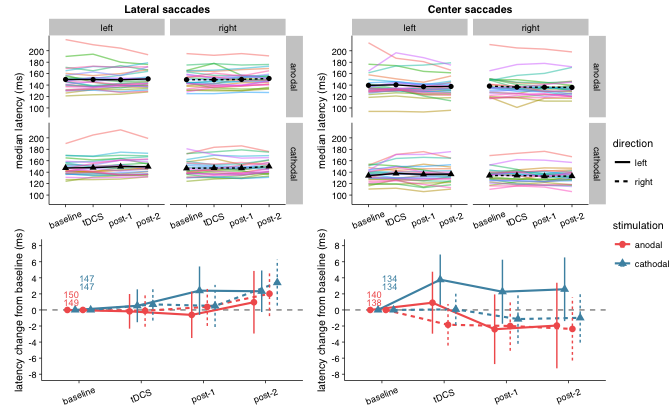

```r
legend_fig4 <- get_legend(plot_group_latency_lateral)
figure_4 <- plot_grid(
  plot_sub_latency_lateral, plot_sub_latency_center,
  plot_group_latency_lateral + theme(legend.position = "none"),
  plot_group_latency_center + theme(legend.position = "none"), rel_heights = c(1,.75))
figure_4 <- plot_grid(figure_4,legend_fig4,rel_widths = c(1,1/10))
figure_4
```

Save the plot:

```r
ggsave("fig/figure_4.pdf", plot = figure_4, width = 180, height = 112.5, units = "mm")
ggsave("fig/figure_4.png", plot = figure_4, width = 180, height = 112.5, units = "mm")
```

### Statistics

#### Contralateral saccades in the anodal session

Means and SDs for effect of *anodal* tDCS on the latency changes in *contralateral* (here: left) *lateral* saccades, as this is what [Kanai et al. (2012)](http://dx.doi.org/10.3389/fpsyt.2012.00045) specifically found:

```r
latencyMedianBaseline %>%
  filter(type == "lateral", stimulation == "anodal", direction == "left", leg != "baseline") %>%
  group_by(leg) %>%
  summarise_at(vars(latency.baseline), funs(mean, sd)) %>%
  kable(.)
```

| leg | mean | sd |
| --- | --- | --- |
| tDCS | -0.1730769 | 5.342176 |
| post.1 | -0.6153846 | 7.134855 |
| post.2 | 0.9615385 | 9.651863 |

#### Baseline tests

```r
latencyMedianLeg %>%
  filter(leg == "baseline") %>%
  group_by(direction,type) %>% # for each of these 4 pairs
  nest() %>% # create a separate data frame of all remaining columns. These data frames are stored in a list-column named "data"
  mutate(stats = map(data, ~t.test(formula = latency~stimulation, paired = TRUE, data =.))) %>% # run t-test on the data frames
  mutate(tidy_model = map(stats, tidy)) %>% # force the four test outputs to also be data frames in a list column ("tidy_model")
  unnest(tidy_model, .drop = TRUE) %>% # unpack the list-column with results, drop the list-column we used to organize the data
  kable(.)
```

| direction | type | estimate | statistic | p.value | parameter | conf.low | conf.high | method | alternative |
| --- | --- | --- | --- | --- | --- | --- | --- | --- | --- |
| left | lateral | 2.403846 | 1.024429 | 0.3154437 | 25 | -2.4289077 | 7.236600 | Paired t-test | two.sided |
| left | center | 5.557692 | 1.910225 | 0.0676402 | 25 | -0.4344207 | 11.549805 | Paired t-test | two.sided |
| right | lateral | 2.769231 | 1.060619 | 0.2990028 | 25 | -2.6081375 | 8.146599 | Paired t-test | two.sided |
| right | center | 4.211538 | 1.657484 | 0.1099194 | 25 | -1.0215893 | 9.444666 | Paired t-test | two.sided |

#### Lateral saccades

##### Classical ANOVA

Repeated measures ANOVA matching [Kanai et al. (2012)](http://dx.doi.org/10.3389/fpsyt.2012.00045).

**Data**: Baseline subtracted, lateral saccades

**Dependent measure**: saccade latency

**Factors**:

- STIMULATION (anodal vs. cathodal)
- LEG (tDCS, post.1, post.2)
- DIRECTION (left vs. right)

Prepare data:

```r
medianLatencyLateralStats <- latencyMedianBaseline %>%
  ungroup() %>%
  filter(leg != "baseline", type == "lateral") %>%
  select(-type) %>%
  mutate(leg = factor(leg, levels = c("tDCS", "post.1", "post.2"))) %>%
  mutate(subject = factor(subject))
```

```r
aovMedianLatencyLateral <- ezANOVA(data = data.frame(medianLatencyLateralStats), dv = latency.baseline, wid = subject, within = .(stimulation,leg,direction), type = 3)
kable(aovMedianLatencyLateral$ANOVA)
```

|  | Effect | DFn | DFd | F | p | p<.05 | ges |
| --- | --- | --- | --- | --- | --- | --- | --- |
| 2 | stimulation | 1 | 25 | 0.8044339 | 0.3783271 |  | 0.0089853 |
| 3 | leg | 2 | 50 | 3.4589912 | 0.0391753 | * | 0.0164093 |
| 4 | direction | 1 | 25 | 0.0864110 | 0.7712172 |  | 0.0003663 |
| 5 | stimulation:leg | 2 | 50 | 0.4014143 | 0.6715104 |  | 0.0007505 |
| 6 | stimulation:direction | 1 | 25 | 0.5221926 | 0.4766141 |  | 0.0012979 |
| 7 | leg:direction | 2 | 50 | 3.6626747 | 0.0327780 | * | 0.0023536 |
| 8 | stimulation:leg:direction | 2 | 50 | 2.5875456 | 0.0852459 |  | 0.0029246 |

```r
kable(aovMedianLatencyLateral$`Mauchly's Test for Sphericity`)
```

|  | Effect | W | p | p<.05 |
| --- | --- | --- | --- | --- |
| 3 | leg | 0.5213492 | 0.0004032 | * |
| 5 | stimulation:leg | 0.6360361 | 0.0043831 | * |
| 7 | leg:direction | 0.7573179 | 0.0355909 | * |
| 8 | stimulation:leg:direction | 0.9123864 | 0.3327710 |  |

```r
kable(aovMedianLatencyLateral$`Sphericity Corrections`)
```

|  | Effect | GGe | p[GG] | p[GG]<.05 | HFe | p[HF] | p[HF]<.05 |
| --- | --- | --- | --- | --- | --- | --- | --- |
| 3 | leg | 0.6762922 | 0.0597258 |  | 0.7012858 | 0.0578252 |  |
| 5 | stimulation:leg | 0.7331572 | 0.6087290 |  | 0.7674993 | 0.6179798 |  |
| 7 | leg:direction | 0.8047111 | 0.0434681 | * | 0.8517313 | 0.0406111 | * |
| 8 | stimulation:leg:direction | 0.9194442 | 0.0903598 |  | 0.9889658 | 0.0859306 |  |

##### Bayesian ANOVA

Same design as the classical ANOVA

Bayes factors agains the null model:

```r
bfMedianLatencyLateral = anovaBF(latency.baseline~stimulation*leg*direction+subject, data = data.frame(medianLatencyLateralStats), whichModels = "withmain", whichRandom = "subject", progress = FALSE, iterations = 100000)
bfMedianLatencyLateral = sort(bfMedianLatencyLateral, decreasing = TRUE) # sort such that winning model is at the top
```

```r
kable(select(extractBF(bfMedianLatencyLateral), bf)) # show only the Bayes factors in a table
```

|  | bf |
| --- | --- |
| leg + subject | 0.8352130 |
| stimulation + subject | 0.7473931 |
| stimulation + leg + subject | 0.6443968 |
| direction + subject | 0.1326109 |
| direction + leg + subject | 0.1130630 |
| stimulation + direction + subject | 0.0992967 |
| stimulation + direction + leg + subject | 0.0858565 |
| stimulation + leg + stimulation:leg + subject | 0.0474197 |
| stimulation + direction + stimulation:direction + subject | 0.0213852 |
| stimulation + direction + stimulation:direction + leg + subject | 0.0191576 |
| direction + leg + direction:leg + subject | 0.0108038 |
| stimulation + direction + leg + direction:leg + subject | 0.0083966 |
| stimulation + direction + leg + stimulation:leg + subject | 0.0064302 |
| stimulation + direction + stimulation:direction + leg + direction:leg + subject | 0.0018561 |
| stimulation + direction + stimulation:direction + leg + stimulation:leg + subject | 0.0014920 |
| stimulation + direction + leg + stimulation:leg + direction:leg + subject | 0.0006257 |
| stimulation + direction + stimulation:direction + leg + stimulation:leg + direction:leg + subject | 0.0001415 |
| stimulation + direction + stimulation:direction + leg + stimulation:leg + direction:leg + stimulation:direction:leg + subject | 0.0000251 |

Inclusion Bayes factor across matched models:

```r
kable(inclusionBF(bfMedianLatencyLateral, models = "matched"))
```

| effect | Bayes.factor |
| --- | --- |
| stimulation | 0.7579226 |
| direction | 0.1335372 |
| stimulation:direction | 0.2194969 |
| leg | 0.8485524 |
| stimulation:leg | 0.0738604 |
| direction:leg | 0.0965650 |
| stimulation:direction:leg | 0.1772191 |

#### Center saccades

##### Classical ANOVA

Repeated measures ANOVA matching [Kanai et al. (2012)](http://dx.doi.org/10.3389/fpsyt.2012.00045).

**Data**: Baseline subtracted, center saccades

**Dependent measure**: saccade latency

**Factors**:

- STIMULATION (anodal vs. cathodal)
- LEG (tDCS, post.1, post.2)
- DIRECTION (left vs. right)

Prepare data:

```r
medianLatencyCenterStats <- latencyMedianBaseline %>%
  ungroup() %>%
  filter(leg != "baseline", type == "center") %>%
  select(-type) %>%
  mutate(leg = factor(leg, levels = c("tDCS", "post.1", "post.2"))) %>%
  mutate(subject = factor(subject))
```

```r
aovMedianLatencyCenter <- ezANOVA(data = data.frame(medianLatencyCenterStats), dv = latency.baseline, wid = subject, within = .(stimulation,leg,direction), type = 3)
kable(aovMedianLatencyCenter$ANOVA)
```

|  | Effect | DFn | DFd | F | p | p<.05 | ges |
| --- | --- | --- | --- | --- | --- | --- | --- |
| 2 | stimulation | 1 | 25 | 3.0937191 | 0.0908311 |  | 0.0230246 |
| 3 | leg | 2 | 50 | 2.3789819 | 0.1030547 |  | 0.0062189 |
| 4 | direction | 1 | 25 | 4.7775590 | 0.0384115 | * | 0.0158632 |
| 5 | stimulation:leg | 2 | 50 | 0.1055936 | 0.8999904 |  | 0.0001735 |
| 6 | stimulation:direction | 1 | 25 | 1.8802459 | 0.1824903 |  | 0.0055307 |
| 7 | leg:direction | 2 | 50 | 3.1018543 | 0.0537187 |  | 0.0016853 |
| 8 | stimulation:leg:direction | 2 | 50 | 1.9636026 | 0.1510262 |  | 0.0012036 |

```r
kable(aovMedianLatencyCenter$`Mauchly's Test for Sphericity`)
```

|  | Effect | W | p | p<.05 |
| --- | --- | --- | --- | --- |
| 3 | leg | 0.5173954 | 0.0003680 | * |
| 5 | stimulation:leg | 0.8690648 | 0.1856204 |  |
| 7 | leg:direction | 0.9230394 | 0.3825099 |  |
| 8 | stimulation:leg:direction | 0.7823535 | 0.0525819 |  |

```r
kable(aovMedianLatencyCenter$`Sphericity Corrections`)
```

|  | Effect | GGe | p[GG] | p[GG]<.05 | HFe | p[HF] | p[HF]<.05 |
| --- | --- | --- | --- | --- | --- | --- | --- |
| 3 | leg | 0.6744887 | 0.1241893 |  | 0.6991962 | 0.1225297 |  |
| 5 | stimulation:leg | 0.8842239 | 0.8774896 |  | 0.9465498 | 0.8902341 |  |
| 7 | leg:direction | 0.9285390 | 0.0579604 |  | 0.9999608 | 0.0537210 |  |
| 8 | stimulation:leg:direction | 0.8212564 | 0.1600417 |  | 0.8713552 | 0.1575428 |  |

##### Bayesian ANOVA

Same design as the classical ANOVA

Bayes factors agains the null model:

```r
bfMedianLatencyCenter = anovaBF(latency.baseline~stimulation*leg*direction+subject, data = data.frame(medianLatencyCenterStats), whichModels = "withmain", whichRandom = "subject", progress = FALSE, iterations = 100000)
bfMedianLatencyCenter = sort(bfMedianLatencyCenter, decreasing = TRUE) # sort such that winning model is at the top
kable(select(extractBF(bfMedianLatencyCenter), bf)) # show only the Bayes factors in a table
```

|  | bf |
| --- | --- |
| stimulation + direction + subject | 532.4650356 |
| stimulation + direction + stimulation:direction + subject | 394.3029430 |
| stimulation + direction + leg + subject | 96.2040603 |
| stimulation + direction + stimulation:direction + leg + subject | 73.5299040 |
| stimulation + subject | 57.7975660 |
| stimulation + direction + leg + direction:leg + subject | 9.6677632 |
| stimulation + leg + subject | 9.4507885 |
| direction + subject | 7.9146682 |
| stimulation + direction + stimulation:direction + leg + direction:leg + subject | 6.8648353 |
| stimulation + direction + leg + stimulation:leg + subject | 6.2949743 |
| stimulation + direction + stimulation:direction + leg + stimulation:leg + subject | 4.9041121 |
| direction + leg + subject | 1.3039416 |
| stimulation + leg + stimulation:leg + subject | 0.6511612 |
| stimulation + direction + leg + stimulation:leg + direction:leg + subject | 0.6412998 |
| stimulation + direction + stimulation:direction + leg + stimulation:leg + direction:leg + subject | 0.4587427 |
| leg + subject | 0.1597575 |
| direction + leg + direction:leg + subject | 0.1261317 |
| stimulation + direction + stimulation:direction + leg + stimulation:leg + direction:leg + stimulation:direction:leg + subject | 0.0850270 |

```r
kable(select(extractBF(bfMedianLatencyCenter), bf)) # show only the Bayes factors in a table
```

|  | bf |
| --- | --- |
| stimulation + direction + subject | 532.4650356 |
| stimulation + direction + stimulation:direction + subject | 394.3029430 |
| stimulation + direction + leg + subject | 96.2040603 |
| stimulation + direction + stimulation:direction + leg + subject | 73.5299040 |
| stimulation + subject | 57.7975660 |
| stimulation + direction + leg + direction:leg + subject | 9.6677632 |
| stimulation + leg + subject | 9.4507885 |
| direction + subject | 7.9146682 |
| stimulation + direction + stimulation:direction + leg + direction:leg + subject | 6.8648353 |
| stimulation + direction + leg + stimulation:leg + subject | 6.2949743 |
| stimulation + direction + stimulation:direction + leg + stimulation:leg + subject | 4.9041121 |
| direction + leg + subject | 1.3039416 |
| stimulation + leg + stimulation:leg + subject | 0.6511612 |
| stimulation + direction + leg + stimulation:leg + direction:leg + subject | 0.6412998 |
| stimulation + direction + stimulation:direction + leg + stimulation:leg + direction:leg + subject | 0.4587427 |
| leg + subject | 0.1597575 |
| direction + leg + direction:leg + subject | 0.1261317 |
| stimulation + direction + stimulation:direction + leg + stimulation:leg + direction:leg + stimulation:direction:leg + subject | 0.0850270 |

Inclusion Bayes factor across matched models:

```r
kable(inclusionBF(bfMedianLatencyCenter, models = "matched"))
```

| effect | Bayes.factor |
| --- | --- |
| stimulation | 67.1698107 |
| direction | 9.3279679 |
| stimulation:direction | 0.7439649 |
| leg | 0.1818340 |
| stimulation:leg | 0.0661683 |
| direction:leg | 0.0974488 |
| stimulation:direction:leg | 0.1853480 |

###### Without S01

```r
medianLatencyCenterNoS01 <- medianLatencyCenterStats %>%
  filter(subject != "S01") %>%
  mutate(subject = factor(subject))
bfMedianLatencyCenterNoS01 = anovaBF(latency.baseline~stimulation*leg*direction+subject, data = data.frame(medianLatencyCenterNoS01), whichModels="withmain", whichRandom = "subject", progress = FALSE, iterations = 100000) # compute Bayes Factors
bfKanaiCenterNoS01 <- sort(bfMedianLatencyCenterNoS01, decreasing = TRUE) # sort such that winning model is at the top
kable(select(extractBF(bfMedianLatencyCenterNoS01), bf)) # show only the Bayes factors in a table
```

|  | bf |
| --- | --- |
| stimulation + subject | 1.9640554 |
| direction + subject | 581.5285256 |
| stimulation + direction + subject | 1377.4254509 |
| stimulation + direction + stimulation:direction + subject | 339.5023767 |
| leg + subject | 0.3012718 |
| stimulation + leg + subject | 0.6170947 |
| direction + leg + subject | 202.3563921 |
| stimulation + direction + leg + subject | 515.9118619 |
| stimulation + direction + stimulation:direction + leg + subject | 127.6249879 |
| stimulation + leg + stimulation:leg + subject | 0.0420750 |
| stimulation + direction + leg + stimulation:leg + subject | 34.0104912 |
| stimulation + direction + stimulation:direction + leg + stimulation:leg + subject | 9.1335465 |
| direction + leg + direction:leg + subject | 25.1494237 |
| stimulation + direction + leg + direction:leg + subject | 63.3338096 |
| stimulation + direction + stimulation:direction + leg + direction:leg + subject | 15.6595568 |
| stimulation + direction + leg + stimulation:leg + direction:leg + subject | 4.1945555 |
| stimulation + direction + stimulation:direction + leg + stimulation:leg + direction:leg + subject | 1.0390094 |
| stimulation + direction + stimulation:direction + leg + stimulation:leg + direction:leg + stimulation:direction:leg + subject | 0.1723584 |

```r
kable(inclusionBF(bfMedianLatencyCenterNoS01, models = "matched"))
```

| effect | Bayes.factor |
| --- | --- |
| stimulation | 2.4178282 |
| direction | 690.8484746 |
| stimulation:direction | 0.2471128 |
| leg | 0.3679517 |
| stimulation:leg | 0.0669569 |
| direction:leg | 0.1230279 |
| stimulation:direction:leg | 0.1658873 |

##### Follow-up tests

###### Main effect of stimulation

Follow-up One-sample t-test:

```r
medianLatencyCenterStats %>%
  group_by(stimulation,subject) %>% # for each session and subject
  summarise(latency = mean(latency.baseline)) %>% # average over all other variables (df is now still grouped per stimulation)
  summarise_if(is.numeric, funs(list(tidy(t.test(.))))) %>%  # run one-sample t-test for each stimulation condition, return tidy data frames
  unnest() %>% # unpack the list-column with data frame for each test
  kable(.)
```

| stimulation | estimate | statistic | p.value | parameter | conf.low | conf.high | method | alternative |
| --- | --- | --- | --- | --- | --- | --- | --- | --- |
| anodal | -1.608974 | -0.9875463 | 0.3328370 | 25 | -4.964508 | 1.746559 | One Sample t-test | two.sided |
| cathodal | 1.096154 | 0.8335773 | 0.4124131 | 25 | -1.612139 | 3.804446 | One Sample t-test | two.sided |

Follow-up Bayesian one-sample t-test:

```r
medianLatencyCenterStats %>%
  group_by(stimulation,subject) %>% # for each session and subject
  summarise(latency = mean(latency.baseline)) %>% # average over all other variables
  spread(stimulation, latency) %>% # make separate columns with test data
  summarise_if(is.numeric, funs(extractBF(ttestBF(.), onlybf = TRUE))) %>% # run Bayesian t-test on each column, keeping only the BF
  gather(stimulation,BF,anodal,cathodal) %>% # make row for each stimulation condition
  kable(.)
```

| stimulation | BF |
| --- | --- |
| anodal | 0.3218926 |
| cathodal | 0.2840670 |

## Saccade endpoint deviation

*See the `accuracy.html` notebook for more explanation and exploration of the saccade endpoint deviation data*

Calculate endpoint deviation for each trial (Euclidian distance from target, defined by x- and y-coordinate deviations)

```r
# Calculate end point deviation
accData <- preproc %>%
  group_by(subject,stimulation,leg,block,trial,direction,type) %>%
  summarise(deviation.end = sqrt(deviation.end.x^2 + deviation.end.y^2))
```

Compute the mean for each 3 blocks

```r
accMeanLeg <- accData %>%
  group_by(subject,stimulation,direction,type) %>%
  summarise(baseline = mean(deviation.end[leg == "pre"]), # take average of 3 blocks, make new column
            tDCS = mean(deviation.end[leg == "tDCS"]),
            post.1 = mean(deviation.end[leg == "post.1"]),
            post.2 = mean(deviation.end[leg == "post.2"])) %>%
  gather(leg,deviation.end,baseline,tDCS,post.1,post.2) %>% # gather new columns to use as factor
  mutate(leg = factor(leg, levels = c("baseline", "tDCS", "post.1", "post.2"))) # reorder factor levels
```

Make a separate data frame where the mean deviation is subtracted from subsequent blocks

```r
accMeanBaseline <- accMeanLeg %>%
  group_by(subject,stimulation,direction,type) %>% # for each condition, subtract baseline scores and make new columns
  summarise(baseline = deviation.end[leg == "baseline"] - deviation.end[leg == "baseline"],
           tDCS = deviation.end[leg == "tDCS"] - deviation.end[leg == "baseline"],
           post.1 = deviation.end[leg == "post.1"] - deviation.end[leg == "baseline"],
           post.2 = deviation.end[leg == "post.2"] - deviation.end[leg == "baseline"]) %>%
  gather(leg, deviation.end.baseline, baseline, tDCS, post.1, post.2)  %>% # gather new columns to use as factor
  mutate(leg = factor(leg, levels = c("baseline", "tDCS", "post.1", "post.2"))) # reorder factor levels
```

### Figure 6

```r
baselineLabelAcc <- accMeanLeg %>%
  group_by(stimulation,direction,type,leg) %>%
  filter(leg == "baseline") %>%
  summarise(deviation.end.baseline = round(mean(deviation.end), digits = 2))
```

Plot mean *lateral saccade* deviation per participant

```r
plot_sub_acc_lateral <- ggplot(filter(accMeanLeg, type == "lateral"), aes(leg, deviation.end)) +
  facet_grid(stimulation ~ direction) +
  geom_line(aes(group = subject, color = subject), alpha = 0.5) +
  stat_summary(fun.y = mean, aes(group = interaction(stimulation, direction), linetype = direction), geom = "line") +
  stat_summary(fun.y = mean, geom = "point", aes(shape = stimulation)) +
  guides(colour = FALSE) +
  scale_x_discrete("time", labels = c("baseline", "tDCS", "post-1", "post-2")) +
  scale_y_continuous(expression("mean deviation " ( degree)), breaks = seq(0.5,2,0.5), limits = c(0.3,2.2)) +
  theme(axis.text.x = element_text(angle = 22, vjust = .5), axis.title.x = element_blank(), legend.position = "none") +
  ggtitle("Lateral saccades")
```

Plot mean *center saccade* deviation per participant

```r
plot_sub_acc_center <- ggplot(filter(accMeanLeg, type == "center"), aes(leg, deviation.end)) +
  facet_grid(stimulation ~ direction) +
  geom_line(aes(group = subject, color = subject), alpha = 0.5) +
  stat_summary(fun.y = mean, aes(group = interaction(stimulation, direction), linetype = direction), geom = "line") +
  stat_summary(fun.y = mean, geom = "point", aes(shape = stimulation)) +
  guides(colour = FALSE) +
  scale_x_discrete("time", labels = c("baseline", "tDCS", "post-1", "post-2")) +
  scale_y_continuous(expression("mean deviation " ( degree)), breaks = seq(0.5,2,0.5), limits = c(0.3,2.2)) +
  theme(axis.text.x = element_text(angle = 22, vjust = .5), axis.title.x = element_blank(), legend.position = "none") +
  ggtitle("Center saccades")
```

Plot group mean *lateral saccade* deviation as change from baseline

```r
plot_group_acc_lateral <- ggplot(filter(accMeanBaseline, type == "lateral"), aes(leg, deviation.end.baseline)) +
  geom_hline(yintercept = 0, linetype = "dashed", size = base_line_size) +
  stat_summary(fun.y = mean, aes(group = interaction(stimulation, direction), color = stimulation, linetype = direction), geom = "line", position = position_dodge(width = 0.5), size = .75) +
  stat_summary(fun.data = mean_cl_normal, aes(group = interaction(stimulation, direction), color = stimulation, linetype = direction), geom = "linerange", position = position_dodge(width = 0.5), show.legend = FALSE) +
  stat_summary(fun.y = mean, aes(group = interaction(stimulation, direction), color = stimulation, shape = stimulation), geom = "point", position = position_dodge(width = 0.5), size = 2) +
  geom_text(data = subset(baselineLabelAcc, type=="lateral"), aes(y = c(.05,.025,.1,.075), label=deviation.end.baseline, color = stimulation), position = position_dodge(width = 0.5), size = mm_to_pt) +
  scale_colour_manual(values = c("#F25F5C", "#4B93B1")) +
  scale_x_discrete("time", labels = c("baseline", "tDCS", "post-1", "post-2")) +
  scale_y_continuous(expression("deviation change from baseline " ( degree)), breaks = seq(-.2,.2,.1)) +
  coord_cartesian(ylim = c(-.22,.22)) +
  theme(axis.text.x = element_text(angle = 22, vjust = .5), axis.title.x = element_blank())
```

Plot group mean *center saccade* deviation as change from baseline

```r
plot_group_acc_center <- ggplot(filter(accMeanBaseline, type == "center"), aes(leg, deviation.end.baseline)) +
  geom_hline(yintercept = 0, linetype = "dashed", size = base_line_size) +
  stat_summary(fun.y = mean, aes(group = interaction(stimulation, direction), color = stimulation, linetype = direction), geom = "line", position = position_dodge(width = 0.5), size = .75) +
  stat_summary(fun.data = mean_cl_normal, aes(group = interaction(stimulation, direction), color = stimulation, linetype = direction), geom = "linerange", position = position_dodge(width = 0.5), show.legend = FALSE) +
  stat_summary(fun.y = mean, aes(group = interaction(stimulation, direction), color = stimulation, shape = stimulation), geom = "point", position = position_dodge(width = 0.5), size = 2) +
  geom_text(data = subset(baselineLabelAcc, type=="center"), aes(y = c(.05,.025,.1,.075), label=deviation.end.baseline, color = stimulation), position = position_dodge(width = 0.5), size = mm_to_pt) +
  scale_colour_manual(values = c("#F25F5C", "#4B93B1")) +
  scale_x_discrete("time", labels = c("baseline", "tDCS", "post-1", "post-2")) +
  scale_y_continuous(expression("deviation change from baseline " ( degree)), breaks = seq(-.2,.2,.1)) +
  coord_cartesian(ylim = c(-.22,.22)) +
  theme(axis.text.x = element_text(angle = 22, vjust = .5), axis.title.x = element_blank())
```

Combine all the plots:

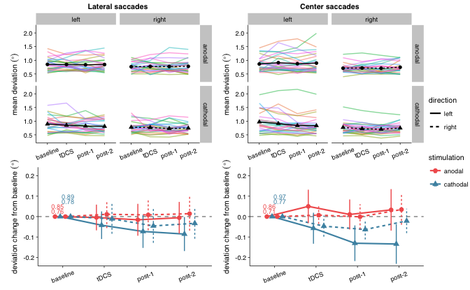

```r
legend_fig6 <- get_legend(plot_group_acc_lateral)
figure_6 <- plot_grid(
  plot_sub_acc_lateral, plot_sub_acc_center,
  plot_group_acc_lateral + theme(legend.position = "none"),
  plot_group_acc_center + theme(legend.position = "none"), rel_heights = c(1,.75))
figure_6 <- plot_grid(figure_6,legend_fig6,rel_widths = c(1,1/10))
figure_6
```

Save the plot:

```r
ggsave("fig/figure_6.pdf", plot = figure_6, width = 180, height = 112.5, units = "mm")
ggsave("fig/figure_6.png", plot = figure_6, width = 180, height = 112.5, units = "mm")
```

### Statistics

#### Baseline tests

```r
accMeanLeg %>%
  filter(leg == "baseline") %>%
  group_by(direction,type) %>%
  nest() %>%
  mutate(stats = map(data, ~t.test(formula = deviation.end~stimulation, paired = TRUE, data =.))) %>% # run t-test on the data frames
  mutate(tidy_model = map(stats, tidy)) %>%
  unnest(tidy_model, .drop = TRUE) %>%
  kable(.)
```

| direction | type | estimate | statistic | p.value | parameter | conf.low | conf.high | method | alternative |
| --- | --- | --- | --- | --- | --- | --- | --- | --- | --- |
| left | lateral | -0.0434955 | -0.9392156 | 0.3566066 | 25 | -0.1388738 | 0.0518827 | Paired t-test | two.sided |
| left | center | -0.1052918 | -2.3796609 | 0.0252737 | 25 | -0.1964194 | -0.0141643 | Paired t-test | two.sided |
| right | lateral | -0.0141028 | -0.4198800 | 0.6781598 | 25 | -0.0832780 | 0.0550724 | Paired t-test | two.sided |
| right | center | -0.0576332 | -1.9185260 | 0.0665325 | 25 | -0.1195025 | 0.0042361 | Paired t-test | two.sided |

#### Differences after baseline

Because there might be a significant baseline difference for center saccades, also print the numerical values for the blocks after, to see whether they continue to differ

```r
accMeanLeg %>%
  filter(leg != "baseline", type == "center") %>%
  group_by(stimulation,direction,leg) %>%
  summarise(mean = mean(deviation.end)) %>%
  kable(.)
```

| stimulation | direction | leg | mean |
| --- | --- | --- | --- |
| anodal | left | tDCS | 0.9149277 |
| anodal | left | post.1 | 0.8752206 |
| anodal | left | post.2 | 0.8978057 |
| anodal | right | tDCS | 0.7192357 |
| anodal | right | post.1 | 0.7110237 |
| anodal | right | post.2 | 0.7465372 |
| cathodal | left | tDCS | 0.9129682 |
| cathodal | left | post.1 | 0.8395323 |
| cathodal | left | post.2 | 0.8357657 |
| cathodal | right | tDCS | 0.7227287 |
| cathodal | right | post.1 | 0.7062460 |
| cathodal | right | post.2 | 0.7483820 |

#### Lateral saccades

##### Classical ANOVAs

Repeated measures ANOVA matching [Kanai et al. (2012)](http://dx.doi.org/10.3389/fpsyt.2012.00045).

**Data**: Baseline subtracted, lateral saccades

**Dependent measure**: saccade endpoint deviation

**Factors**:

- STIMULATION (anodal vs. cathodal)
- LEG (tDCS, post.1, post.2)
- DIRECTION (left vs. right)

Prepare data:

```r
meanAccLateralStats <- accMeanBaseline %>%
  ungroup() %>%
  filter(leg != "baseline", type == "lateral") %>%
  select(-type) %>%
  mutate(leg = factor(leg, levels = c("tDCS", "post.1", "post.2"))) %>%
  mutate(subject = factor(subject))
```

```r
aovMeanAccLateral <- ezANOVA(data = data.frame(meanAccLateralStats), dv = deviation.end.baseline, wid = subject, within = .(stimulation,leg,direction), type = 3)
kable(aovMeanAccLateral$ANOVA)
```

|  | Effect | DFn | DFd | F | p | p<.05 | ges |
| --- | --- | --- | --- | --- | --- | --- | --- |
| 2 | stimulation | 1 | 25 | 2.0266072 | 0.1669269 |  | 0.0178886 |
| 3 | leg | 2 | 50 | 0.8985792 | 0.4136202 |  | 0.0021712 |
| 4 | direction | 1 | 25 | 1.5739544 | 0.2212365 |  | 0.0059023 |
| 5 | stimulation:leg | 2 | 50 | 0.5863132 | 0.5601540 |  | 0.0015026 |
| 6 | stimulation:direction | 1 | 25 | 0.1283222 | 0.7231851 |  | 0.0005433 |
| 7 | leg:direction | 2 | 50 | 0.1400779 | 0.8696305 |  | 0.0002306 |
| 8 | stimulation:leg:direction | 2 | 50 | 0.2773853 | 0.7589209 |  | 0.0002720 |

```r
kable(aovMeanAccLateral$`Mauchly's Test for Sphericity`)
```

|  | Effect | W | p | p<.05 |
| --- | --- | --- | --- | --- |
| 3 | leg | 0.6913883 | 0.0119307 | * |
| 5 | stimulation:leg | 0.9959286 | 0.9522226 |  |
| 7 | leg:direction | 0.9738561 | 0.7276748 |  |
| 8 | stimulation:leg:direction | 0.7556773 | 0.0346766 | * |

```r
kable(aovMeanAccLateral$`Sphericity Corrections`)
```

|  | Effect | GGe | p[GG] | p[GG]<.05 | HFe | p[HF] | p[HF]<.05 |
| --- | --- | --- | --- | --- | --- | --- | --- |
| 3 | leg | 0.7641686 | 0.3907386 |  | 0.8038793 | 0.3951392 |  |
| 5 | stimulation:leg | 0.9959451 | 0.5595027 |  | 1.0819912 | 0.5601540 |  |
| 7 | leg:direction | 0.9745222 | 0.8646202 |  | 1.0558164 | 0.8696305 |  |
| 8 | stimulation:leg:direction | 0.8036501 | 0.7108179 |  | 0.8504748 | 0.7234385 |  |

##### Bayesian ANOVA

Same design as the classical ANOVA (without order effect)

Bayes factors agains the null model:

```r
bfMeanAccLateral = anovaBF(deviation.end.baseline~stimulation*leg*direction+subject, data = data.frame(meanAccLateralStats), whichModels = "withmain", whichRandom = "subject", progress = FALSE, iterations = 100000)
bfMeanAccLateral = sort(bfMeanAccLateral, decreasing = TRUE) # sort such that winning model is at the top
```

```r
kable(select(extractBF(bfMeanAccLateral), bf)) # show only the Bayes factors in a table
```

|  | bf |
| --- | --- |
| stimulation + subject | 6.3400523 |
| stimulation + direction + subject | 3.2378043 |
| stimulation + direction + stimulation:direction + subject | 0.6225693 |
| direction + subject | 0.4416518 |
| stimulation + leg + subject | 0.3429758 |
| stimulation + direction + leg + subject | 0.1648642 |
| leg + subject | 0.0534535 |
| stimulation + direction + stimulation:direction + leg + subject | 0.0298322 |
| stimulation + leg + stimulation:leg + subject | 0.0290925 |
| direction + leg + subject | 0.0236635 |
| stimulation + direction + leg + stimulation:leg + subject | 0.0131121 |
| stimulation + direction + leg + direction:leg + subject | 0.0103604 |
| stimulation + direction + stimulation:direction + leg + stimulation:leg + subject | 0.0026128 |
| stimulation + direction + stimulation:direction + leg + direction:leg + subject | 0.0021340 |
| direction + leg + direction:leg + subject | 0.0016002 |
| stimulation + direction + leg + stimulation:leg + direction:leg + subject | 0.0009068 |
| stimulation + direction + stimulation:direction + leg + stimulation:leg + direction:leg + subject | 0.0001694 |
| stimulation + direction + stimulation:direction + leg + stimulation:leg + direction:leg + stimulation:direction:leg + subject | 0.0000207 |

Inclusion Bayes factor across matched models:

```r
kable(inclusionBF(bfMeanAccLateral, models = "matched"))
```

| effect | Bayes.factor |
| --- | --- |
| stimulation | 6.6405313 |
| direction | 0.4997822 |
| stimulation:direction | 0.1918029 |
| leg | 0.0528075 |
| stimulation:leg | 0.0834174 |
| direction:leg | 0.0648087 |
| stimulation:direction:leg | 0.1221503 |

#### Center saccades

##### Classical ANOVA

Repeated measures ANOVA matching [Kanai et al. (2012)](http://dx.doi.org/10.3389/fpsyt.2012.00045).

**Data**: Baseline subtracted, center saccades

**Dependent measure**: saccade endpoint deviation

**Factors**:

- STIMULATION (anodal vs. cathodal)
- LEG (tDCS, post.1, post.2)
- DIRECTION (left vs. right)

Prepare data:

```r
meanAccCenterStats <- accMeanBaseline %>%
  ungroup() %>%
  filter(leg != "baseline", type == "center") %>%
  select(-type) %>%
  mutate(leg = factor(leg, levels = c("tDCS", "post.1", "post.2"))) %>%
  mutate(subject = factor(subject))
```

```r
aovMeanAccCenter <- ezANOVA(data = data.frame(meanAccCenterStats), dv = deviation.end.baseline, wid = subject, within = .(stimulation,leg,direction), type = 3)
kable(aovMeanAccCenter$ANOVA)
```

|  | Effect | DFn | DFd | F | p | p<.05 | ges |
| --- | --- | --- | --- | --- | --- | --- | --- |
| 2 | stimulation | 1 | 25 | 10.3422560 | 0.0035735 | * | 0.0698321 |
| 3 | leg | 2 | 50 | 2.4132849 | 0.0998788 |  | 0.0064777 |
| 4 | direction | 1 | 25 | 0.4250384 | 0.5203830 |  | 0.0041044 |
| 5 | stimulation:leg | 2 | 50 | 0.6101220 | 0.5472793 |  | 0.0012937 |
| 6 | stimulation:direction | 1 | 25 | 2.7995910 | 0.1067576 |  | 0.0126867 |
| 7 | leg:direction | 2 | 50 | 3.8854661 | 0.0270094 | * | 0.0071117 |
| 8 | stimulation:leg:direction | 2 | 50 | 0.5883554 | 0.5590374 |  | 0.0011173 |

```r
kable(aovMeanAccCenter$`Mauchly's Test for Sphericity`)
```

|  | Effect | W | p | p<.05 |
| --- | --- | --- | --- | --- |
| 3 | leg | 0.8436804 | 0.1300575 |  |
| 5 | stimulation:leg | 0.9603861 | 0.6156733 |  |
| 7 | leg:direction | 0.6656519 | 0.0075677 | * |
| 8 | stimulation:leg:direction | 0.8210183 | 0.0938067 |  |

```r
kable(aovMeanAccCenter$`Sphericity Corrections`)
```

|  | Effect | GGe | p[GG] | p[GG]<.05 | HFe | p[HF] | p[HF]<.05 |
| --- | --- | --- | --- | --- | --- | --- | --- |
| 3 | leg | 0.8648128 | 0.1084443 |  | 0.9232826 | 0.1046730 |  |
| 5 | stimulation:leg | 0.9618956 | 0.5412918 |  | 1.0404345 | 0.5472793 |  |
| 7 | leg:direction | 0.7494296 | 0.0403283 | * | 0.7865648 | 0.0380011 | * |
| 8 | stimulation:leg:direction | 0.8481896 | 0.5328387 |  | 0.9034188 | 0.5428502 |  |

##### Bayesian ANOVA

Same design as the classical ANOVA

Bayes factors agains the null model:

```r
bfMeanAccCenter = anovaBF(deviation.end.baseline~stimulation*leg*direction+subject, data = data.frame(meanAccCenterStats), whichModels = "withmain", whichRandom = "subject", progress = FALSE, iterations = 100000)
bfMeanAccCenter = sort(bfMeanAccCenter, decreasing = TRUE) # sort such that winning model is at the top
```

```r
kable(select(extractBF(bfMeanAccCenter), bf)) # show only the Bayes factors in a table
```

|  | bf |
| --- | --- |
| stimulation + subject | 4.106449e+04 |
| stimulation + direction + stimulation:direction + subject | 1.856891e+04 |
| stimulation + direction + subject | 1.103494e+04 |
| stimulation + leg + subject | 4.229288e+03 |
| stimulation + direction + stimulation:direction + leg + subject | 1.906850e+03 |
| stimulation + direction + leg + subject | 1.075423e+03 |
| stimulation + leg + stimulation:leg + subject | 3.390460e+02 |
| stimulation + direction + stimulation:direction + leg + direction:leg + subject | 3.346668e+02 |
| stimulation + direction + leg + direction:leg + subject | 2.146401e+02 |
| stimulation + direction + stimulation:direction + leg + stimulation:leg + subject | 1.424011e+02 |
| stimulation + direction + leg + stimulation:leg + subject | 8.365876e+01 |
| stimulation + direction + stimulation:direction + leg + stimulation:leg + direction:leg + subject | 2.972238e+01 |
| stimulation + direction + leg + stimulation:leg + direction:leg + subject | 1.698275e+01 |
| stimulation + direction + stimulation:direction + leg + stimulation:leg + direction:leg + stimulation:direction:leg + subject | 3.404441e+00 |
| direction + subject | 2.423604e-01 |
| leg + subject | 9.609780e-02 |
| direction + leg + subject | 2.243320e-02 |
| direction + leg + direction:leg + subject | 4.178900e-03 |

Inclusion Bayes factor across matched models:

```r
kable(inclusionBF(bfMeanAccCenter, models = "matched"))
```

| effect | Bayes.factor |
| --- | --- |
| stimulation | 4.220938e+04 |
| direction | 2.672197e-01 |
| stimulation:direction | 1.688649e+00 |
| leg | 1.020479e-01 |
| stimulation:leg | 7.883280e-02 |
| direction:leg | 1.857701e-01 |
| stimulation:direction:leg | 1.145413e-01 |

##### Follow-up tests

###### Main effect of stimulation

Follow-up One-sample t-test:

```r
meanAccCenterStats %>%
  group_by(stimulation,subject) %>% # for each session and subject
  summarise(deviation = mean(deviation.end.baseline)) %>% # average over all other variables (df is now still grouped per stimulation)
  summarise_if(is.numeric, funs(list(tidy(t.test(.))))) %>%  # run one-sample t-test for each stimulation condition, return tidy data frames
  unnest() %>% # unpack the list-column with data frame for each test
  kable(.)
```

| stimulation | estimate | statistic | p.value | parameter | conf.low | conf.high | method | alternative |
| --- | --- | --- | --- | --- | --- | --- | --- | --- |
| anodal | 0.0223864 | 0.9712741 | 0.3407160 | 25 | -0.0250828 | 0.0698555 | One Sample t-test | two.sided |
| cathodal | -0.0755975 | -3.1803958 | 0.0038987 | 25 | -0.1245524 | -0.0266426 | One Sample t-test | two.sided |

Follow-up Bayesian one-sample t-test:

```r
meanAccCenterStats %>%
  group_by(stimulation,subject) %>% # for each session and subject
  summarise(deviation = mean(deviation.end.baseline)) %>% # average over all other variables
  spread(stimulation, deviation) %>% # make separate columns with test data
  summarise_if(is.numeric, funs(extractBF(ttestBF(.), onlybf = TRUE))) %>% # run Bayesian t-test on each column, keeping only the BF
  gather(stimulation,BF,anodal,cathodal) %>% # make row for each stimulation condition
  kable(.)
```

| stimulation | BF |
| --- | --- |
| anodal | 0.3173718 |
| cathodal | 10.5264920 |

## Saccade endpoint variability

*See the `accuracy.html` notebook for more explanation and exploration of the saccade endpoint variability data*

Calculate endpoint variability, as standard deviation of the horizontal component (x-coordinate) of saccades

```r
varMeanLeg <- preproc %>%
  group_by(subject,stimulation,leg,direction,type) %>%
  summarise(std.deviation.x = sd(deviation.end.x)) %>% # standard deviation
  ungroup() %>%
  mutate(leg = as.character(leg), # edit leg factor to match other data frames
         leg = replace(leg, leg == "pre", "baseline"),
         leg = factor(leg, levels = c("baseline", "tDCS", "post.1", "post.2"))
         )
```

Make a separate data frame where the mean variability is subtracted from subsequent blocks

```r
varMeanBaseline <- varMeanLeg %>%
  group_by(subject,stimulation,direction,type) %>% # for each condition, subtract baseline scores and make new columns
  summarise(baseline = std.deviation.x[leg == "baseline"] - std.deviation.x[leg == "baseline"],
           tDCS = std.deviation.x[leg == "tDCS"] - std.deviation.x[leg == "baseline"],
           post.1 = std.deviation.x[leg == "post.1"] - std.deviation.x[leg == "baseline"],
           post.2 = std.deviation.x[leg == "post.2"] - std.deviation.x[leg == "baseline"]) %>%
  gather(leg, std.deviation.x.baseline, baseline, tDCS, post.1, post.2)  %>% # gather new columns to use as factor
  mutate(leg = factor(leg, levels = c("baseline", "tDCS", "post.1", "post.2"))) # reorder factor levels
```

### Figure 7

```r
baselineLabelVar <- varMeanLeg %>%
  group_by(stimulation,direction,type,leg) %>%
  filter(leg == "baseline") %>%
  summarise(std.deviation.x.baseline = round(mean(std.deviation.x), digits = 2))
```

Plot mean *lateral saccade* variability per participant

```r
plot_sub_var_lateral <- ggplot(filter(varMeanLeg, type == "lateral"), aes(leg, std.deviation.x)) +
  facet_grid(stimulation ~ direction) +
  geom_line(aes(group = subject, color = subject), alpha = 0.5) +
  stat_summary(fun.y = mean, aes(group = interaction(stimulation, direction), linetype = direction), geom = "line") +
  stat_summary(fun.y = mean, geom = "point", aes(shape = stimulation)) +
  guides(colour = FALSE) +
  scale_x_discrete("time", labels = c("baseline", "tDCS", "post-1", "post-2")) +
  scale_y_continuous(expression("standard deviation " ( degree)), breaks = seq(0.5,2,0.5), limits = c(0,2)) +
  theme(axis.text.x = element_text(angle = 22, vjust = .5), axis.title.x = element_blank(), legend.position = "none") +
  ggtitle("Lateral saccades")
```

Plot mean *center saccade* variability per participant

```r
plot_sub_var_center <- ggplot(filter(varMeanLeg, type == "center"), aes(leg, std.deviation.x)) +
  facet_grid(stimulation ~ direction) +
  geom_line(aes(group = subject, color = subject), alpha = 0.5) +
  stat_summary(fun.y = mean, aes(group = interaction(stimulation, direction), linetype = direction), geom = "line") +
  stat_summary(fun.y = mean, geom = "point", aes(shape = stimulation)) +
  guides(colour = FALSE) +
  scale_x_discrete("time", labels = c("baseline", "tDCS", "post-1", "post-2")) +
  scale_y_continuous(expression("standard deviation " ( degree)), breaks = seq(0.5,2,0.5), limits = c(0,2)) +
  theme(axis.text.x = element_text(angle = 22, vjust = .5), axis.title.x = element_blank(), legend.position = "none") +
  ggtitle("Center saccades")
```

Plot group mean *lateral saccade* variability as change from baseline

```r
plot_group_var_lateral <- ggplot(filter(varMeanBaseline, type == "lateral"), aes(leg, std.deviation.x.baseline)) +
  geom_hline(yintercept = 0, linetype = "dashed", size = base_line_size) +
  stat_summary(fun.y = mean, aes(group = interaction(stimulation, direction), color = stimulation, linetype = direction), geom = "line", position = position_dodge(width = 0.5), size = .75) +
  stat_summary(fun.data = mean_cl_normal, aes(group = interaction(stimulation, direction), color = stimulation, linetype = direction), geom = "linerange", position = position_dodge(width = 0.5), show.legend = FALSE) +
  stat_summary(fun.y = mean, aes(group = interaction(stimulation, direction), color = stimulation, shape = stimulation), geom = "point", position = position_dodge(width = 0.5), size = 2) +
  geom_text(data = subset(baselineLabelVar, type=="lateral"), aes(y = c(.05,.025,.1,.075), label=(std.deviation.x.baseline), color = stimulation), position = position_dodge(width = 0.5), size = mm_to_pt) +
  scale_x_discrete("time", labels = c("baseline", "tDCS", "post-1", "post-2")) +
  scale_colour_manual(values = c("#F25F5C", "#4B93B1")) +
  scale_y_continuous(expression("SD change from baseline " ( degree)), breaks = seq(-.2,.2,.1)) +
  coord_cartesian(ylim = c(-.2,.2)) +
  theme(axis.text.x = element_text(angle = 22, vjust = .5), axis.title.x = element_blank())
```

Plot group mean *center saccade* variability as change from baseline

```r
plot_group_var_center <- ggplot(filter(varMeanBaseline, type == "center"), aes(leg, std.deviation.x.baseline)) +
  geom_hline(yintercept = 0, linetype = "dashed", size = base_line_size) +
  stat_summary(fun.y = mean, aes(group = interaction(stimulation, direction), color = stimulation, linetype = direction), geom = "line", position = position_dodge(width = 0.5), size = .75) +
  stat_summary(fun.data = mean_cl_normal, aes(group = interaction(stimulation, direction), color = stimulation, linetype = direction), geom = "linerange", position = position_dodge(width = 0.5), show.legend = FALSE) +
  stat_summary(fun.y = mean, aes(group = interaction(stimulation, direction), color = stimulation, shape = stimulation), geom = "point", position = position_dodge(width = 0.5), size = 2) +
  geom_text(data = subset(baselineLabelVar, type=="center"), aes(y = c(.05,.025,.1,.075), label=(std.deviation.x.baseline), color = stimulation), position = position_dodge(width = 0.5), size = mm_to_pt) +
  scale_colour_manual(values = c("#F25F5C", "#4B93B1")) +
  scale_x_discrete("time", labels = c("baseline", "tDCS", "post-1", "post-2")) +
  scale_y_continuous(expression("SD change from baseline " ( degree)), breaks = seq(-.2,.2,.1)) +
  coord_cartesian(ylim = c(-.2,.2)) +
  theme(axis.text.x = element_text(angle = 22, vjust = .5), axis.title.x = element_blank())
```

Combine all the plots:

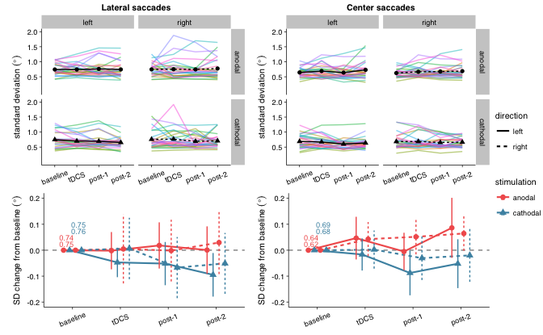

```r
legend_fig7 <- get_legend(plot_group_acc_lateral)
figure_7 <- plot_grid(
  plot_sub_var_lateral, plot_sub_var_center,
  plot_group_var_lateral + theme(legend.position = "none"),
  plot_group_var_center + theme(legend.position = "none"), rel_heights = c(1,.75))
figure_7 <- plot_grid(figure_7,legend_fig7,rel_widths = c(1,1/10))
figure_7
```

Save the plot:

```r
ggsave("fig/figure_7.pdf", plot = figure_7, width = 180, height = 112.5, units = "mm")
ggsave("fig/figure_7.png", plot = figure_7, width = 180, height = 112.5, units = "mm")
```

### Statistics

#### Baseline tests

```r
varMeanLeg %>%
  filter(leg == "baseline") %>%
  group_by(direction,type) %>%
  nest() %>%
  mutate(stats = map(data, ~t.test(formula = std.deviation.x~stimulation, paired = TRUE, data =.))) %>% # run t-test on the data frames
  mutate(tidy_model = map(stats, tidy)) %>%
  unnest(tidy_model, .drop = TRUE) %>%
  kable(.)
```

| direction | type | estimate | statistic | p.value | parameter | conf.low | conf.high | method | alternative |
| --- | --- | --- | --- | --- | --- | --- | --- | --- | --- |
| left | lateral | -0.0046841 | -0.0964036 | 0.9239687 | 25 | -0.1047541 | 0.0953859 | Paired t-test | two.sided |
| left | center | -0.0436919 | -0.9898113 | 0.3317503 | 25 | -0.1346033 | 0.0472195 | Paired t-test | two.sided |
| right | lateral | -0.0130790 | -0.2683130 | 0.7906600 | 25 | -0.1134716 | 0.0873137 | Paired t-test | two.sided |
| right | center | -0.0597899 | -1.3048234 | 0.2038368 | 25 | -0.1541625 | 0.0345827 | Paired t-test | two.sided |

#### Lateral saccades

##### Classical ANOVA

Repeated measures ANOVA matching [Kanai et al. (2012)](http://dx.doi.org/10.3389/fpsyt.2012.00045).

**Data**: Baseline subtracted, lateral saccades

**Dependent measure**: saccade endpoint variability (x-coordinate standard deviation)

**Factors**:

- STIMULATION (anodal vs. cathodal)
- LEG (tDCS, post.1, post.2)
- DIRECTION (left vs. right)

Prepare data:

```r
meanVarLateralStats <- varMeanBaseline %>%
  ungroup() %>%
  filter(leg != "baseline", type == "lateral") %>%
  select(-type) %>%
  mutate(leg = factor(leg, levels = c("tDCS", "post.1", "post.2"))) %>%
  mutate(subject = factor(subject))
```

```r
aovMeanVarLateral <- ezANOVA(data = data.frame(meanVarLateralStats), dv = std.deviation.x.baseline, wid = subject, within = .(stimulation,leg,direction), type = 3)
kable(aovMeanVarLateral$ANOVA)
```

|  | Effect | DFn | DFd | F | p | p<.05 | ges |
| --- | --- | --- | --- | --- | --- | --- | --- |
| 2 | stimulation | 1 | 25 | 1.2189602 | 0.2800786 |  | 0.0138324 |
| 3 | leg | 2 | 50 | 0.4518157 | 0.6390443 |  | 0.0011604 |
| 4 | direction | 1 | 25 | 0.2471961 | 0.6234009 |  | 0.0010690 |
| 5 | stimulation:leg | 2 | 50 | 1.1183082 | 0.3348684 |  | 0.0030580 |
| 6 | stimulation:direction | 1 | 25 | 0.1204196 | 0.7314841 |  | 0.0004919 |
| 7 | leg:direction | 2 | 50 | 0.9403214 | 0.3972980 |  | 0.0023341 |
| 8 | stimulation:leg:direction | 2 | 50 | 0.1873223 | 0.8297557 |  | 0.0003276 |

```r
kable(aovMeanVarLateral$`Mauchly's Test for Sphericity`)
```

|  | Effect | W | p | p<.05 |
| --- | --- | --- | --- | --- |
| 3 | leg | 0.994425 | 0.9351138 |  |
| 5 | stimulation:leg | 0.994966 | 0.9412372 |  |
| 7 | leg:direction | 0.908637 | 0.3167270 |  |
| 8 | stimulation:leg:direction | 0.903796 | 0.2970605 |  |

```r
kable(aovMeanVarLateral$`Sphericity Corrections`)
```

|  | Effect | GGe | p[GG] | p[GG]<.05 | HFe | p[HF] | p[HF]<.05 |
| --- | --- | --- | --- | --- | --- | --- | --- |
| 3 | leg | 0.9944559 | 0.6379765 |  | 1.0801686 | 0.6390443 |  |
| 5 | stimulation:leg | 0.9949912 | 0.3346792 |  | 1.0808237 | 0.3348684 |  |
| 7 | leg:direction | 0.9162854 | 0.3907925 |  | 0.9851512 | 0.3961957 |  |
| 8 | stimulation:leg:direction | 0.9122389 | 0.8102650 |  | 0.9802676 | 0.8255939 |  |

##### Bayesian ANOVA

Same design as the classical ANOVA

Bayes factors agains the null model:

```r
bfMeanVarLateral = anovaBF(std.deviation.x.baseline~stimulation*leg*direction+subject, data = data.frame(meanVarLateralStats), whichModels = "withmain", whichRandom = "subject", progress = FALSE, iterations = 100000)
bfMeanVarLateral = sort(bfMeanVarLateral, decreasing = TRUE) # sort such that winning model is at the top
```

```r
kable(select(extractBF(bfMeanVarLateral), bf)) # show only the Bayes factors in a table
```

|  | bf |
| --- | --- |
| stimulation + subject | 1.6368279 |
| stimulation + direction + subject | 0.2417691 |
| direction + subject | 0.1488644 |
| stimulation + leg + subject | 0.0689523 |
| stimulation + direction + stimulation:direction + subject | 0.0457505 |
| leg + subject | 0.0424994 |
| stimulation + direction + leg + subject | 0.0102944 |
| stimulation + leg + stimulation:leg + subject | 0.0071935 |
| direction + leg + subject | 0.0063189 |
| stimulation + direction + stimulation:direction + leg + subject | 0.0020441 |
| stimulation + direction + leg + stimulation:leg + subject | 0.0011732 |
| stimulation + direction + leg + direction:leg + subject | 0.0009725 |
| direction + leg + direction:leg + subject | 0.0006015 |
| stimulation + direction + stimulation:direction + leg + stimulation:leg + subject | 0.0002020 |
| stimulation + direction + stimulation:direction + leg + direction:leg + subject | 0.0001766 |
| stimulation + direction + leg + stimulation:leg + direction:leg + subject | 0.0000997 |
| stimulation + direction + stimulation:direction + leg + stimulation:leg + direction:leg + subject | 0.0000248 |
| stimulation + direction + stimulation:direction + leg + stimulation:leg + direction:leg + stimulation:direction:leg + subject | 0.0000022 |

Inclusion Bayes factor across matched models:

```r
kable(inclusionBF(bfMeanVarLateral, models = "matched"))
```

| effect | Bayes.factor |
| --- | --- |
| stimulation | 1.6346841 |
| direction | 0.1482214 |
| stimulation:direction | 0.1895258 |
| leg | 0.0423365 |
| stimulation:leg | 0.1054485 |
| direction:leg | 0.0935982 |
| stimulation:direction:leg | 0.0890821 |

#### Center saccades

##### Classical ANOVA

Repeated measures ANOVA matching [Kanai et al. (2012)](http://dx.doi.org/10.3389/fpsyt.2012.00045).

**Data**: Baseline subtracted, center saccades

**Dependent measure**: saccade endpoint variability (x-coordinate standard deviation)

**Factors**:

- STIMULATION (anodal vs. cathodal)
- LEG (tDCS, post.1, post.2)
- DIRECTION (left vs. right)

Prepare data:

```r
meanVarCenterStats <- varMeanBaseline %>%
  ungroup() %>%
  filter(leg != "baseline", type == "center") %>%
  select(-type) %>%
  mutate(leg = factor(leg, levels = c("tDCS", "post.1", "post.2"))) %>%
  mutate(subject = factor(subject))
```

```r
aovMeanVarCenter <- ezANOVA(data = data.frame(meanVarCenterStats), dv = std.deviation.x.baseline, wid = subject, within = .(stimulation,leg,direction), type = 3)
kable(aovMeanVarCenter$ANOVA)
```

|  | Effect | DFn | DFd | F | p | p<.05 | ges |
| --- | --- | --- | --- | --- | --- | --- | --- |
| 2 | stimulation | 1 | 25 | 3.8851203 | 0.0598820 |  | 0.0399400 |
| 3 | leg | 2 | 50 | 2.7073528 | 0.0764935 |  | 0.0075993 |
| 4 | direction | 1 | 25 | 0.6021177 | 0.4450504 |  | 0.0033319 |
| 5 | stimulation:leg | 2 | 50 | 1.1805422 | 0.3155254 |  | 0.0036640 |
| 6 | stimulation:direction | 1 | 25 | 0.1745759 | 0.6796436 |  | 0.0010192 |
| 7 | leg:direction | 2 | 50 | 2.1601871 | 0.1259451 |  | 0.0035285 |
| 8 | stimulation:leg:direction | 2 | 50 | 0.4735067 | 0.6255786 |  | 0.0007475 |

```r
kable(aovMeanVarCenter$`Mauchly's Test for Sphericity`)
```

|  | Effect | W | p | p<.05 |
| --- | --- | --- | --- | --- |
| 3 | leg | 0.8960127 | 0.2677749 |  |
| 5 | stimulation:leg | 0.8569616 | 0.1568686 |  |
| 7 | leg:direction | 0.6679634 | 0.0078892 | * |
| 8 | stimulation:leg:direction | 0.8089994 | 0.0785921 |  |

```r
kable(aovMeanVarCenter$`Sphericity Corrections`)
```

|  | Effect | GGe | p[GG] | p[GG]<.05 | HFe | p[HF] | p[HF]<.05 |
| --- | --- | --- | --- | --- | --- | --- | --- |
| 3 | leg | 0.9058075 | 0.0824883 |  | 0.9725125 | 0.0781996 |  |
| 5 | stimulation:leg | 0.8748612 | 0.3116036 |  | 0.9353175 | 0.3136546 |  |
| 7 | leg:direction | 0.7507301 | 0.1405427 |  | 0.7880908 | 0.1383445 |  |
| 8 | stimulation:leg:direction | 0.8396302 | 0.5929099 |  | 0.8932129 | 0.6044505 |  |

##### Bayesian ANOVA

Same design as the classical ANOVA

Bayes factors agains the null model:

```r
bfMeanVarCenter = anovaBF(std.deviation.x.baseline~stimulation*leg*direction+subject, data = data.frame(meanVarCenterStats), whichModels = "withmain", whichRandom = "subject", progress = FALSE, iterations = 100000)
bfMeanVarCenter = sort(bfMeanVarCenter, decreasing = TRUE) # sort such that winning model is at the top
```

```r
kable(select(extractBF(bfMeanVarCenter), bf)) # show only the Bayes factors in a table
```

|  | bf |
| --- | --- |
| stimulation + subject | 143.7876035 |
| stimulation + direction + subject | 31.3002062 |
| stimulation + leg + subject | 17.5164038 |
| stimulation + direction + stimulation:direction + subject | 6.7862297 |
| stimulation + direction + leg + subject | 3.8038501 |
| stimulation + leg + stimulation:leg + subject | 1.9714300 |
| stimulation + direction + stimulation:direction + leg + subject | 0.7871364 |
| stimulation + direction + leg + stimulation:leg + subject | 0.4324661 |
| stimulation + direction + leg + direction:leg + subject | 0.4314291 |
| direction + subject | 0.2146647 |
| leg + subject | 0.1156607 |
| stimulation + direction + stimulation:direction + leg + direction:leg + subject | 0.1042781 |
| stimulation + direction + stimulation:direction + leg + stimulation:leg + subject | 0.0871906 |
| stimulation + direction + leg + stimulation:leg + direction:leg + subject | 0.0449988 |
| direction + leg + subject | 0.0257119 |
| stimulation + direction + stimulation:direction + leg + stimulation:leg + direction:leg + subject | 0.0097944 |
| direction + leg + direction:leg + subject | 0.0026869 |
| stimulation + direction + stimulation:direction + leg + stimulation:leg + direction:leg + stimulation:direction:leg + subject | 0.0011799 |

Inclusion Bayes factor across matched models:

```r
kable(inclusionBF(bfMeanVarCenter, models = "matched"))
```

| effect | Bayes.factor |
| --- | --- |
| stimulation | 144.8708224 |
| direction | 0.2176328 |
| stimulation:direction | 0.2158843 |
| leg | 0.1215190 |
| stimulation:leg | 0.1124351 |
| direction:leg | 0.1154880 |
| stimulation:direction:leg | 0.1204699 |

##### Follow-up tests

###### Main effect of stimulation

Follow-up One-sample t-test:

```r
meanVarCenterStats %>%
  group_by(stimulation,subject) %>% # for each session and subject
  summarise(std.deviation.x. = mean(std.deviation.x.baseline)) %>% # average over all other variables (df is now still grouped per stimulation)
  summarise_if(is.numeric, funs(list(tidy(t.test(.))))) %>%  # run one-sample t-test for each stimulation condition, return tidy data frames
  unnest() %>% # unpack the list-column with data frame for each test
  kable(.)
```

| stimulation | estimate | statistic | p.value | parameter | conf.low | conf.high | method | alternative |
| --- | --- | --- | --- | --- | --- | --- | --- | --- |
| anodal | 0.0477794 | 1.683151 | 0.1047947 | 25 | -0.0106845 | 0.1062434 | One Sample t-test | two.sided |
| cathodal | -0.0340719 | -1.236236 | 0.2278603 | 25 | -0.0908350 | 0.0226911 | One Sample t-test | two.sided |

Follow-up Bayesian one-sample t-test:

```r
meanVarCenterStats %>%
  group_by(stimulation,subject) %>% # for each session and subject
  summarise(std.deviation.x = mean(std.deviation.x.baseline)) %>% # average over all other variables
  spread(stimulation, std.deviation.x) %>% # make separate columns with test data
  summarise_if(is.numeric, funs(extractBF(ttestBF(.), onlybf = TRUE))) %>% # run Bayesian t-test on each column, keeping only the BF
  gather(stimulation,BF,anodal,cathodal) %>% # make row for each stimulation condition
  kable(.)
```

| stimulation | BF |
| --- | --- |
| anodal | 0.7138830 |
| cathodal | 0.4103342 |

# Quantile analysis

*See the `RT_quantiles.html` notebook for more explanation and exploration of the saccade latency distribution data*

Estimate quantiles and compute shift function:

```r
qData <- groupData %>%
  filter(!is.na(latency)) %>% # discard missing saccades
  group_by(subject,leg,type,direction) %>% # for each condition
  nest(stimulation,latency) %>% # make a list_column "data" out of the stimulation and latency columns. Now, each group has its own data frame consisting of the stimulation and latency columns for that group
  mutate(shift = purrr::map(data, ~ shiftdhd_pbci(., formula = latency ~ stimulation, nboot = 2000))) # for each group, estimate quantiles and compute shift function, and store as a list column in "shift"

qData <- unnest(qData,shift) # unpack the list column to get the model results for each group in the original data frame

# Alternatively, instead of "nest ...", "mutate ..." and "unnest ...", you can call shiftdhd through dplyr::do (but this is basically depreated in favor of purrr:map)
# do(shiftdhd(.[,c("stimulation","latency")], formula = latency ~ stimulation, nboot = 100)) # estimate quantiles and compute shift function
```

Note that this takes quite a while to compute with a large number of bootstrap samples, so we will load the result from disk in the next code chunk. By default, the chunk above will not run becuase of the `eval=FALSE` statement; remove this to execute it and compute the result from scratch.

```r
qData <- read_csv(here("data", "sacc-tDCS_quantiles.csv")) %>%
  filter(!(subject %in% subs2exclude)) %>% # exclude subjects
    mutate(leg = replace(leg, leg == "pre", "baseline"), # rename and reoder levels
         leg = replace(leg, leg == "post.1", "post-1"),
         leg = replace(leg, leg == "post.2", "post-2"),
         leg = factor(leg, levels = c("baseline", "tDCS", "post-1", "post-2")))
```

```r
qStats <- qData %>%
  group_by(subject,leg,type,direction) %>%
  mutate(deco = c(seq(1,5),seq(4,1))) %>% # add code of deciles to data frame
  group_by(leg,type,direction,q) %>%
  mutate(anodal = mean(anodal)) %>% # mean of "anodal" quantiles OVER subjects
  group_by(leg,type,direction) %>%
  mutate(anodal_median = median(anodal)) # median for plotting
```

For each quantile, count which subjects show significant effects, and in which direction

```r
qSig <- qData %>%
  group_by(subject,leg,type,direction,q) %>%
  mutate(significance = NA,
         # If (anodal - cathodal) quantile difference is positive, latency for anodal > latency for cathodal
         significance = replace(significance, p_value < p_crit & difference > 0, "cathodal.faster"),
         # If (anodal - cathodal) quantile difference is negative, latency for anodal < latency for cathodal
         significance = replace(significance, p_value < p_crit & difference < 0, "anodal.faster")
  )
```

## Figure 5

Shift functions for *lateral saccades*

```r
plot_shift_lateral <- ggplot(filter(qStats, type == "lateral"), aes(anodal, difference)) +
   facet_grid(leg ~ direction) +
   geom_hline(yintercept = 0, linetype = "dashed", alpha = 0.5) +
   geom_vline(aes(xintercept = anodal_median), linetype = "dashed", alpha = 0.5) +
   stat_summary(fun.data = mean_cl_normal, geom = "linerange", colour = "black", size = 0.5) +
   stat_summary(fun.y = mean, geom = "line", size = 1, colour = "grey50", alpha = 0.5) +
   stat_summary(fun.y = mean, geom = "point", aes(fill = deco), size = 2, colour = "black", shape = 21) +
   scale_fill_gradient(low = "white", high = "grey30", guide = FALSE) +
   scale_x_continuous("anodal deciles (ms)", limits = c(80,200), breaks = seq(100,200,25)) +
   scale_y_continuous("anodal - cathodal deciles (ms)")
```

Number of subjects with signifcant difference per quantile for lateral saccades

```r
plot_sig_lateral <- ggplot(filter(qSig, type == "lateral", !is.na(significance)), aes(q, fill = significance)) +
  facet_grid(leg ~ direction) +
  geom_bar(position = "stack") +
  stat_bin(binwidth = .1, geom = "text", size = mm_to_pt, aes(label = ..count..), position = position_stack(vjust = 0.5)) +
  scale_fill_manual(values = c("#F25F5C", "#4B93B1")) +
  scale_x_continuous("decile", breaks = seq(0.1,0.9,0.1), labels = seq(1,9,1)) +
  scale_y_continuous("number of participants with significant difference", limits = c(0, length(unique(qSig$subject))), breaks = c(0,10,20,length(unique(qSig$subject))))
```

Shift functions for *center saccades*

```r
plot_shift_center <- ggplot(filter(qStats, type == "center"), aes(anodal, difference)) +
   facet_grid(leg ~ direction) +
   geom_hline(yintercept = 0, linetype = "dashed", alpha = 0.5) +
   geom_vline(aes(xintercept = anodal_median), linetype = "dashed", alpha = 0.5) +
   stat_summary(fun.data = mean_cl_normal, geom = "linerange", colour = "black", size = 0.5) +
   stat_summary(fun.y = mean, geom = "line", size = 1, colour = "grey50", alpha = 0.5) +
   stat_summary(fun.y = mean, geom = "point", aes(fill = deco), size = 2, colour = "black", shape = 21) +
   scale_fill_gradient(low = "white", high = "grey30", guide = FALSE) +
   scale_x_continuous("anodal deciles (ms)", limits = c(80,200), breaks = seq(100,200,25)) +
   scale_y_continuous("anodal - cathodal deciles (ms)")
```

```r
plot_sig_center <- ggplot(filter(qSig, type == "center", !is.na(significance)), aes(q, fill = significance)) +
  facet_grid(leg ~ direction) +
  geom_bar(position = "stack") +
  stat_bin(binwidth = .1, geom = "text", size = mm_to_pt, aes(label = ..count..), position = position_stack(vjust = 0.5)) +
  scale_fill_manual(values = c("#F25F5C", "#4B93B1")) +
  scale_x_continuous("decile", breaks = seq(0.1,0.9,0.1), labels = seq(1,9,1)) +
  scale_y_continuous("number of participants with significant difference", limits = c(0, length(unique(qSig$subject))), breaks = c(0,10,20,length(unique(qSig$subject))))
```

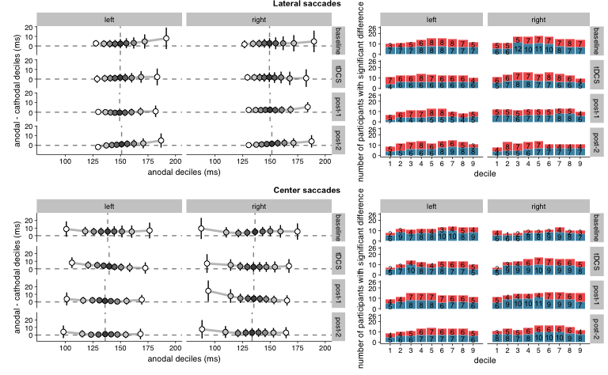

```r
figure_5_lateral <- plot_grid(plot_shift_lateral, plot_sig_lateral + theme(legend.position = "none"), rel_widths = c(1.33,1)) # top row
figure_5_center <- plot_grid(plot_shift_center,plot_sig_center + theme(legend.position = "none"), rel_widths = c(1.33,1)) # bottom row
#title objects
title_lateral <- ggdraw() + draw_label("Lateral saccades", fontface = 'bold', size = base_font_size)
title_center <- ggdraw() + draw_label("Center saccades", fontface = 'bold', size = base_font_size)
#combine with titles
figure_5_lateral <- plot_grid(title_lateral, figure_5_lateral, ncol = 1, rel_heights = c(0.05, 1))
figure_5_center <- plot_grid(title_center, figure_5_center, ncol = 1, rel_heights = c(0.05, 1))
figure_5 <- plot_grid(figure_5_lateral, figure_5_center, nrow = 2)
figure_5
```

Save the plot:

```r
ggsave("fig/figure_5.pdf", plot = figure_5, width = 180, height = 180, units = "mm")
ggsave("fig/figure_5.png", plot = figure_5, width = 180, height = 180 , units = "mm")
```

# Supplementary results

## tDCS adverse effect questionnaire

*See the `questionnaires.html` notebook for more explanation and exploration of the questionnaire data*

```r
# Load the data frame
dataFile <- here("data", "tdcs_sensations.csv")
sensData <- read_csv2(dataFile, col_types = cols(
  session = col_factor(c("first","second")),
  stimulation = col_factor(c("anodal","cathodal"))
))
kable(head(sensData)) # show data frame
```

| subject | session | stimulation | itching | tingling | burning | pain | headache | fatigue | dizziness | nausea | conf.itching | conf.tingling | conf.burning | conf.pain | conf.headache | conf.fatigue | conf.dizziness | conf.nausea | felt.more |
| --- | --- | --- | --- | --- | --- | --- | --- | --- | --- | --- | --- | --- | --- | --- | --- | --- | --- | --- | --- |
| S01 | first | cathodal | 2 | 4 | 4 | 2 | 0 | 0 | 0 | 0 | 3 | 4 | 4 | 4 | 0 | 0 | 0 | 0 | cathode |
| S01 | second | anodal | 1 | 1 | 1 | 0 | 0 | 1 | 0 | 0 | 4 | 4 | 4 | 0 | 0 | 1 | 0 | 0 | anode |
| S02 | first | anodal | 1 | 2 | 2 | 0 | 0 | 1 | 0 | 0 | 4 | 4 | 4 | 0 | 0 | 1 | 0 | 0 | anode |
| S02 | second | cathodal | 1 | 2 | 2 | 0 | 0 | 0 | 0 | 0 | 4 | 4 | 4 | 0 | 0 | 0 | 0 | 0 | equal |
| S03 | first | cathodal | 0 | 0 | 0 | 0 | 0 | 0 | 0 | 0 | 0 | 0 | 0 | 0 | 0 | 0 | 0 | 0 | equal |
| S03 | second | anodal | 0 | 0 | 0 | 0 | 0 | 0 | 0 | 0 | 0 | 0 | 0 | 0 | 0 | 0 | 0 | 0 | equal |

Participants were asked to which degree the following sensations were present during stimulation: *tingling*, *itching sensation*, *burning sensation*, *pain*, *headache*, *fatigue*, *dizziness* and *nausea*. Each was rated on a scale from 0-4:

0. none
1. a little
2. moderate
3. strong
4. very strong

They also rated their confidence *that the sensations were caused by the stimulation* on a scale from 0-4 (columns starting with `conf.`):

0. n/a (meaning they rated the sensation a 0 on the previous scale)
1. unlikely
2. possibly
3. likely
4. very likely

**Factors**:

- *subject*: subject ID (`S01`, `S02`, etc)
- *session*: Whether data are from the `first` or `second` session
- *stimulation*: Whether data are from the `anodal` or `cathodal` session

Calculate how many anodal and cathodal sessions were rated:

```r
idxComplete <- rowSums(is.na(sensData)) != ncol(sensData) - 3 # rows that do not have all NAs (except the 3 factor columns)
# calculate number of questionnaires completed per stimulation type
nAnodal <- sum(sensData$stimulation == "anodal" & idxComplete)
nCathodal <- sum(sensData$stimulation == "cathodal" & idxComplete)
```

### Figure S1

Prepare the sensation intensity and confidence ratings.

```r
# Make long form data frame of sensation intensity
ratings <- sensData %>%
  select(everything(), -contains("conf"), -felt.more) %>% # drop other columns
  gather(sensation, rating, itching:nausea) # make long form
# Make long form data frame of sensation confidence
confidence <- sensData %>%
  select(contains("conf"), subject, session, stimulation) %>%
  gather(sensation, confidence, conf.itching:conf.nausea) %>%
  mutate(sensation = str_replace(sensation, "conf.", "")) # get rid of "conf." prefix so it matches the sensation intensity tibble
# Join the two data frames
sensDataLong <- dplyr::full_join(ratings,confidence)
```

Make plot of sensation distribution:

```r
plot_sensation <- ggplot(sensDataLong, aes(rating, fill = stimulation)) +
    facet_wrap(~sensation, nrow = 1) +
    geom_bar(position = "stack") +
    stat_bin(binwidth = 1, geom = "text", size = mm_to_pt, aes(label = ..count..), position = position_stack(vjust = 0.5)) +
    scale_fill_manual(values = c("#F25F5C", "#4B93B1")) +
    xlim(0.5,4.5) + # exclude "0" ratings that were not present
    ylim(0,35) + # bound plot at max number of ratings
    ylab("number of sessions") +
  ggtitle("Sensation intensity")
```

Make plot of confidence distribution:

```r
plot_confidence <- ggplot(sensDataLong, aes(confidence, fill = stimulation)) +
    facet_wrap(~sensation, nrow = 1) +
    geom_bar(position = "stack") +
    stat_bin(binwidth = 1, geom = "text", size = mm_to_pt, aes(label = ..count..), position = position_stack(vjust = 0.5)) +
    scale_fill_manual(values = c("#F25F5C", "#4B93B1")) +
    xlim(0.5,4.5) +
    ylim(0,35) +
    xlab("ratings") +
    ylab("number of sessions") +
    ggtitle("Confidence")
```

Put together and show plot:

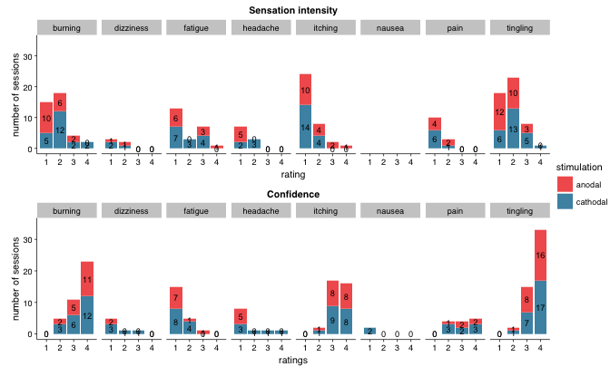

```r
legend_S1 <- get_legend(plot_sensation)
figure_S1 <- plot_grid(
  plot_sensation + theme(legend.position = "none"),
  plot_confidence + theme(legend.position = "none"),
  nrow = 2)
figure_S1 <- plot_grid(figure_S1,legend_S1, rel_widths = c(1,1/10))
figure_S1
```

Save the plot:

```r
ggsave("fig/figure_S1.pdf", plot = figure_S1, width = 180, height = 112.5, units = "mm")
ggsave("fig/figure_S1.png", plot = figure_S1, width = 180, height = 112.5, units = "mm")
```

### Statistics

Mann-Whitney U tests for difference in sensation intensity ratings between anodal and cathodal sessions.

```r
sensationList <- c("itching", "tingling", "burning", "pain", "headache", "fatigue", "dizziness", "nausea")
senseTests <- data.frame(sensation = sensationList, p.value = NA) # initialize results data frame
for (item in sensationList) {
  testData <- sensData[[item]] # extract column with test dat
  tmp <- wilcox.test(testData[sensData$stimulation == "anodal"], testData[sensData$stimulation == "cathodal"])
  senseTests$p.value[senseTests$sensation %in% item] <- tmp$p.value # put p-value in row of results data frame
}
kable(senseTests)
```

| sensation | p.value |
| --- | --- |
| itching | 0.5787360 |
| tingling | 0.3652154 |
| burning | 0.1913439 |
| pain | 0.9287263 |
| headache | 0.9648458 |
| fatigue | 0.4330014 |
| dizziness | 0.7203021 |
| nausea | NaN |

Note that the p-value for “nausea” is undefined because it was never reported (i.e. all ranks are tied at 0).

## Frontal eye field coordinates

*See the `frontal_eye_field.html` notebook for more explanation and exploration of the frontal eye field coordinate data*

### Native space

These were determined for each subject’s scan; see `neuronav_notes.md` for further info.

```r
dataFile <- here("data", "FEF_coords_native.csv")
nativeCoords <- read_csv2(dataFile)
nativeCoords %>%
  select(-folder, -scan) %>% # drop columns with folder and scan names
  filter(!(subject %in% subs2exclude)) %>% # drop rows with excluded subjects
  kable(.)
```

| subject | native.X | native.Y | native.Z |
| --- | --- | --- | --- |
| S01 | 96 | 132 | 137 |
| S02 | 89 | 118 | 132 |
| S03 | 153 | 124 | 177 |
| S04 | 96 | 127 | 131 |
| S05 | 93 | 116 | 138 |
| S06 | 101 | 131 | 182 |
| S07 | 92 | 127 | 147 |
| S08 | 101 | 123 | 159 |
| S09 | 99 | 125 | 158 |
| S10 | 94 | 124 | 125 |
| S11 | 147 | 123 | 149 |
| S12 | 97 | 121 | 176 |
| S13 | 144 | 125 | 140 |
| S14 | 87 | 122 | 129 |
| S15 | 118 | 111 | 125 |
| S17 | 161 | 135 | 175 |
| S18 | 153 | 147 | 173 |
| S19 | 146 | 155 | 172 |
| S20 | 78 | 124 | 99 |
| S24 | 160 | 134 | 141 |
| S26 | 156 | 141 | 150 |
| S27 | 148 | 122 | 156 |
| S29 | 90 | 131 | 153 |
| S30 | 95 | 125 | 149 |
| S32 | 147 | 140 | 146 |
| S33 | 159 | 149 | 168 |

### MNI space (Table S1)

Load in the coordinates that were transformed to MNI space.

#### Table S1

```r
dataFile <- here("data", "FEF_coords_MNI.csv")
mniCoords <- read_delim(dataFile, ";")
mniCoords <- filter(mniCoords, !(subject %in% subs2exclude)) # exclude subjects
mniCoords %>%
  select(-folder, -scan) %>% # drop columns with folder and scan names
  kable(.)
```

| subject | MNI_X | MNI_Y | MNI_Z |
| --- | --- | --- | --- |
| S01 | 29.4081 | 1.069700 | 54.8724 |
| S02 | 33.0338 | -2.245090 | 50.4239 |
| S03 | 30.5837 | -1.480360 | 50.5881 |
| S04 | 25.7061 | -3.761730 | 56.3648 |
| S05 | 29.7780 | -5.201110 | 55.8046 |
| S06 | 29.7783 | -1.120820 | 58.2622 |
| S07 | 38.1233 | 2.975730 | 45.9613 |
| S08 | 31.5014 | 0.526375 | 45.6200 |
| S09 | 28.5103 | 3.632940 | 51.2804 |
| S10 | 28.1080 | -1.933630 | 50.7210 |
| S11 | 30.5811 | -3.787490 | 51.9535 |
| S12 | 36.5129 | -0.386049 | 46.7630 |
| S13 | 26.2263 | -1.069220 | 54.7079 |
| S14 | 37.5005 | -1.588150 | 52.5889 |
| S15 | 31.8188 | -8.357000 | 58.9671 |
| S17 | 31.0229 | -5.121250 | 54.3116 |
| S18 | 34.9669 | 8.390570 | 49.8188 |
| S19 | 28.0703 | -3.834910 | 52.7607 |
| S20 | 41.2127 | -1.745790 | 47.5514 |
| S24 | 37.3474 | -0.862753 | 43.4371 |
| S26 | 34.3288 | -2.861210 | 49.1761 |
| S27 | 27.6566 | -10.061100 | 50.9743 |
| S29 | 30.3161 | -5.272910 | 55.2661 |
| S30 | 26.8320 | -3.868670 | 54.5619 |
| S32 | 29.0049 | 4.888810 | 49.1404 |
| S33 | 30.3099 | -3.897600 | 50.9083 |

#### Descriptives

Calculate descriptive statistics over subjects:

```r
mniCoords %>%
  gather(dimension, coord, MNI_X:MNI_Z) %>%
  group_by(dimension) %>%
  summarise_at(vars(coord), funs(mean, min, max, sd)) %>%
  kable(.)
```

| dimension | mean | min | max | sd |
| --- | --- | --- | --- | --- |
| MNI_X | 31.470735 | 25.7061 | 41.21270 | 4.036810 |
| MNI_Y | -1.806643 | -10.0611 | 8.39057 | 3.931623 |
| MNI_Z | 51.645608 | 43.4371 | 58.96710 | 3.922225 |